# gradient_descent_intuition

### Click Here for notes on Gradinet Descent

```python
import pandas as pd
import numpy as np
import matplotlib.pyplot as plt
% matplotlib inline
from sklearn.base import BaseEstimator, TransformerMixin
from sklearn.pipeline import Pipeline
```

```python
linear_dataset = pd.read_csv('../data/linear_set.csv')
X = linear_dataset['input_feature'].values
y= linear_dataset['output_feature'].values
y = y.reshape(-1,1)
```

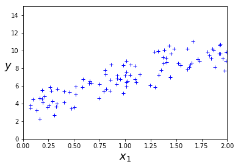

```python
plt.plot(X, y, "b+")
plt.xlabel("$x_1$", fontsize=18)
plt.ylabel("$y$", rotation=0, fontsize=18)
plt.axis([0, 2, 0, 15])
plt.show()
```

```python
X_b = np.c_[np.ones((100, 1)), X]  # add x0 = 1 to each instance
```

```python
eta = 0.1
n_iterations = 1000
m = 100
theta_gd = np.random.randn(2,1)

for iteration in range(n_iterations):
    gradients = 2/m * X_b.T.dot(X_b.dot(theta_gd) - y)
    theta_gd = theta_gd - eta * gradients
```

```python
theta_gd
```

```
array([[ 3.64705943],
       [ 3.25466668]])
```

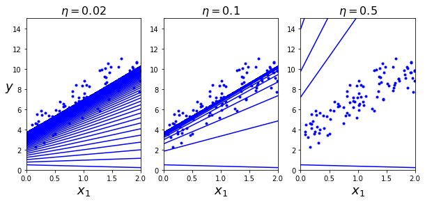

```python
X_new = np.array([[0], [2]])
X_new_b = np.c_[np.ones((2, 1)), X_new]

def plot_gradient_descent(theta, eta):
    m = len(X_b)
    plt.plot(X, y, "b.")
    n_iterations = 1000
    for iteration in range(n_iterations):
        y_predict = X_new_b.dot(theta)
        plt.plot(X_new, y_predict, "b-")
        gradients = 2/m * X_b.T.dot(X_b.dot(theta) - y)
        theta = theta - eta * gradients
    plt.xlabel("$x_1$", fontsize=18)
    plt.axis([0, 2, 0, 15])
    plt.title(r"$\eta = {}$".format(eta), fontsize=16)

np.random.seed(42)
theta = np.random.randn(2,1)  # random initialization

plt.figure(figsize=(10,4))
plt.subplot(131); plot_gradient_descent(theta, eta=0.02)
plt.ylabel("$y$", rotation=0, fontsize=18)
plt.subplot(132); plot_gradient_descent(theta, eta=0.1)
plt.subplot(133); plot_gradient_descent(theta, eta=0.5)

plt.show()
```

- On the left, the learning rate is too low: the algorithm will eventually reach the solution, but it will take a long time.
- In the middle, the learning rate looks pretty good: in just a few iterations, it has already converged to the solution.
- On the right, the learning rate is too high: the algorithm diverges, jumping all over the place and actually getting further and further away from the solution at every step.
- However, you may want to limit the number of iterations so that grid search can eliminate models that take too long to converge.
- **How to set the number of iterations:**
  - -> If it is too low, you will still be far away from the optimal solution when the algorithm stops.
  - -> If it is too high, you will waste time while the model parameters do not change anymore.
  - A simple solution is to set a very large number of iterations but to interrupt the algorithm when the gradient vector becomes tiny — ϵ (called the tolerance) — because this happens when Gradient Descent has (almost) reached the minimum.
- Disadvantage:The main problem with Batch Gradient Descent is that it uses the whole training set to compute the gradients at every step, which makes it very slow when the training set is large.

### Stochastic Gradient Descent

- Stochastic Gradient Descent picks a random instance in the training set at every step and computes the gradients based only on that single instance. Obviously this makes the algorithm much faster since it has very little data to manipulate at every iteration. It also makes it possible to train on huge training sets, since only one instance needs to be in memory at each iteration.
- On the other hand, due to its stochastic (i.e., random) nature, this algorithm is much less regular than Batch Gradient Descent. Instead of gently decreasing until it reaches the minimum, the cost function will bounce up and down, decreasing only on average. Over time it will end up very close to the minimum, but once it gets there it will continue to bounce around (image below), never settling down. So once the algorithm stops, the final parameter values are good, but not optimal.

[figure not shown]

- When the cost function is very irregular (non-convex), this (cost function bouncing up and down) can actually help the algorithm jump out of local minima, so Stochastic Gradient Descent has a **better chance of finding the global minimum** than Batch Gradient Descent does. Therefore **randomness is good to escape from local optima, but bad because it means that the algorithm can never settle at the minimum**.
- **Solution to this dilemma is to gradually reduce the learning rate**. The steps start out large (which helps make quick progress and escape local minima), then get smaller and smaller, allowing the algorithm to settle at the global minimum. This process is called **simulated annealing**, because it resembles the process of annealing in metallurgy where molten metal is slowly cooled down. The function that determines the learning rate at each iteration is called the learning schedule. If the learning rate is reduced too quickly, you may get stuck in a local minimum, or even end up frozen halfway to the minimum. If the learning rate is reduced too slowly, you may jump around the minimum for a long time and end up with a suboptimal solution if you halt training too early.

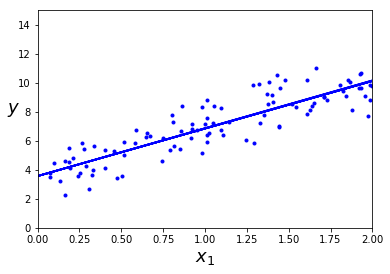

```python
np.random.seed(42)
m = len(X_b)
n_epochs = 50
t0, t1 = 5, 50  # learning schedule hyperparameters

def learning_schedule(t):
    return t0 / (t + t1)

theta = np.random.randn(2,1)  # random initialization

for epoch in range(n_epochs):
    for i in range(m):
        if epoch == 20 and i < 20:                # see what happens to blue line in higher epochs, i.e., 20, 21, ...
            y_predict = X_new_b.dot(theta)
            plt.plot(X_new, y_predict, "b-")
        random_index = np.random.randint(m)
        xi = X_b[random_index:random_index+1]
        yi = y[random_index:random_index+1]
        gradients = 2 * xi.T.dot(xi.dot(theta) - yi)
        eta = learning_schedule(epoch * m + i)
        theta = theta - eta * gradients

plt.plot(X, y, "b.")
plt.xlabel("$x_1$", fontsize=18)
plt.ylabel("$y$", rotation=0, fontsize=18)
plt.axis([0, 2, 0, 15])
plt.show()
```

```python
theta
```

```
array([[ 3.62592079],
       [ 3.26473501]])
```

### Mini-Batch Gradient Descent

- Mini-batch Gradient Descent computes the gradients on small random sets of instances called mini-batches. The main advantage of Mini-batch GD over Stochastic GD is that you can get a performance boost from hardware optimization of matrix operations, especially when using GPUs.
- The algorithm’s progress in parameter space is less erratic than with SGD, especially with fairly large mini-batches. As a result, Mini-batch GD will end up walking around a bit closer to the minimum than SGD. But, on the other hand, it may be harder for it to escape from local minima.

| Algorithm | large m (samples) | large n(features) | Hyperparams | Need Scaling? | Scikit-Learn |
| --- | --- | --- | --- | --- | --- |
| Normal Equation | Fast | Slow | 0 | No | LinearRegression |
| Batch GD | Slow | Fast | 2 | Yes | NA |
| Stochastic GD | Fast | Fast | >2 | Yes | SGDRegressor |
| Mini-Batch GD | Fast | Slow | >2 | Yes | NA |

### Early Stopping

- A very different way to regularize iterative learning algorithms such as Gradient Descent is to stop training as soon as the validation error reaches a minimum. This is called early stopping. As the epochs go by, the algorithm learns and its prediction error (RMSE) on the training set naturally goes down, and so does its prediction error on the validation set. However, after a while the validation error stops decreasing and actually starts to go back up. This indicates that the model has started to overfit the training data. With early stopping you just stop training as soon as the validation error reaches the minimum. It is such a simple and **efficient regularization technique** that Geoffrey Hinton called it a “beautiful free lunch.”